# cabDataProject

Anthony Saita, Juna Iafelice, Joelle Bracco, Nicholas Weidner

5/24/2020

### Purpose of the Project

Yellow Cabs have become synonymous with New York City. Though struggling with the onslaught on new entrants from shared ride services, New York Yellow Cabs remain an immensely convenient and accessible means of transportation in a city of 8 million inhabitants. This project will examine the raw data associated with Yellow Cabs in New York from the perspective of a cab driver. Given the 130 million rows of data, how can a cab driver parse usable information without getting lost in a forest of data? This project seeks to provide cab driver with useable information to maximize their tipping profits and maximize their days to provide the highest profitability possible in a city inundated with competition.

### Overview of Data

The data on Yellow Cab trips was obtained from https://www1.nyc.gov/site/tlc/about/tlc-trip-record-data.page, a New York City organization dedicated to tracking cab data for various purposes that are outlined in the above link. For more granular analysis, the data is divided into the 12 months of the year. After combining all the data sets, the Taxi Zone Lookup Table was added to the combined data file to provide borough and neighborhood information for each pickup and dropoff location. Without the inner joined table, the pickup and dropoff locations would be simple numeric identifiers.  
After this inner join, the taxiCabData2018 variable was created, but 130 million rows were far too onerous for the group’s systems to work with in a quick and reliable manner. Use sample_n of 1,000,000 rows from each month, a 12 million row data set entitled nycTaxiData2018 was created. To further enhance usability further, this new dataset of 12 million was converted into a tibble, with the datetime columns separated into date and time (by seconds). After the tibble creation, work began on the cleaning of the data.

### Data Dictionary for Columns

To better understand the data set, it’s important to follow the data dictionary and variables the group decided were important to the success of the project. Accordingly, the following link: https://www1.nyc.gov/assets/tlc/downloads/pdf/data_dictionary_trip_records_yellow.pdf details the column names and their descriptions. Nothing was edited from the source material except for the following: tpep_pick_datetime and tpep_dropoff_datetime were changed divided into Pickup_Date/Pickup_Time and Dropoff_Date/Dropoff_Time. The _date variables are formatted as dates in format of yyyymmdd. The times are in hms format in seconds, which were converted into minutes for the purposes of analysis. In addition, Pickup_Location_ID and Dropoff_Location_ID were divided into PULocationID, PU_Borough, PU_Neighbourhood, and PU_ServiceZone. The Borough and Neighborhood provide character variables with the name of the boroughs and neighborhoods in NYC.

### Data Cleaning

The data set was cleaned in the following ways:

1. All trips that had negative time values were excluded from the dataset. (i.e. Dropoff_Time-Pickup_Time must be greater than 0)
2. The Pickup_Date must be between 2018-01-01 and 2018-12-31
3. Trip length is over 0 miles.
4. Trip length is less than 32 miles (The distance between Newark and LaGuardia Airports)

The resulting data set, taxiDataClean, contained 11,785,260 out of 12,000,000 original rows of data. This equates to a loss of 1.8% of the data.

### Testing Data for Centrality

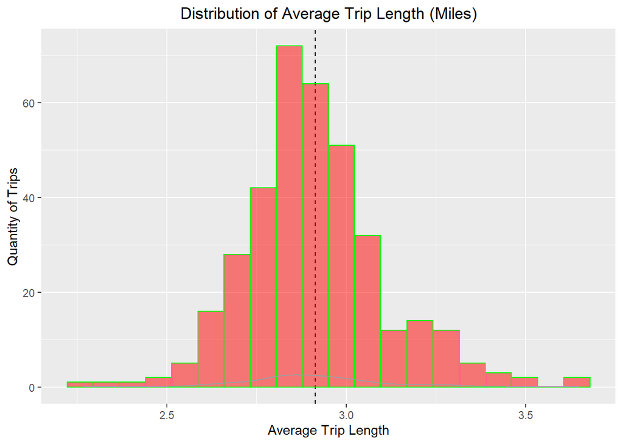

```r
### Test Plot
ggplot(data=AverageTripLength, aes(x=avgTripLength))+
  geom_vline(aes(xintercept = mean(avgTripLength)), linetype = 2)+
  geom_histogram(bins=20, fill='red', color="green", alpha=0.5)+
  geom_density(col=200) +
  labs(x="Average Trip Length", y = "Quantity of Trips") +
  ggtitle("Distribution of Average Trip Length (Miles)") +
  theme(plot.title = element_text(hjust = 0.5))
```

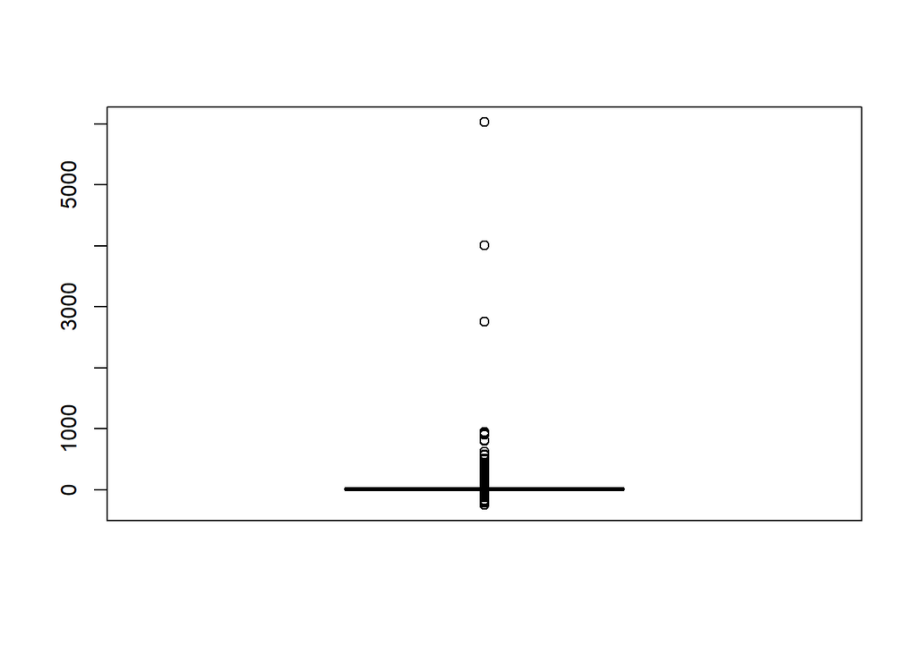

```r
### Test Plot
boxplot(taxiDataClean$Total_Charge_to_Passengers)
```

### Predictions and Approach

Our group is approaching our theory from the lens of maximizing daily income for a proposective Yellow Cab driver. For many, a large part of their income that they have “control” over is the tips that they are able to generate, both daily and per ride. Our group theorizes that not only do the two direct inputs to calculating fare: Trip Duration and distance factor into the total tip, but Time of Day and Day of the week do as well. Payment types other than credit cards have been excluded, as Tip Data is not tracked for non-credit card tips. In order to analyze potential models of these variables, they will need to be added to the dataframe, and then we can run a random forest as well as a conventional lm() model and check for significance.

### Random Forest and Model

```r
fitted_forest <- randomForest(formula = Tip_Percent ~ Trip_Distance_Miles + Trip_Duration + hour + wday + month,
                              data =taxiTipData,
                              ntree = 80, sampsize = 10000)

print(fitted_forest)
```

```
##
## Call:
##  randomForest(formula = Tip_Percent ~ Trip_Distance_Miles + Trip_Duration +      hour + wday + month, data = taxiTipData, ntree = 80, sampsize = 10000)
##                Type of random forest: regression
##                      Number of trees: 80
## No. of variables tried at each split: 1
##
##           Mean of squared residuals: 34.68162
##                     % Var explained: 1.68
```

```r
importance(fitted_forest)
```

```
##                     IncNodePurity
## Trip_Distance_Miles     33749.140
## Trip_Duration           37989.904
## hour                    18230.882
## wday                     9894.321
## month                   13338.657
```

```r
TipModel <- lm(Tip_Percent~ Trip_Distance_Miles + Trip_Duration + hour + wday + month, taxiTipData)
summary(TipModel)
```

```
##
## Call:
## lm(formula = Tip_Percent ~ Trip_Distance_Miles + Trip_Duration +
##     hour + wday + month, data = taxiTipData)
##
## Residuals:
##     Min      1Q  Median      3Q     Max
## -19.914  -1.664   0.392   1.017  81.863
##
## Coefficients:
##                       Estimate Std. Error  t value Pr(>|t|)
## (Intercept)         19.9087959  0.0058074 3428.171  < 2e-16 ***
## Trip_Distance_Miles -0.0255051  0.0008273  -30.831  < 2e-16 ***
## Trip_Duration       -0.0274959  0.0002384 -115.341  < 2e-16 ***
## hour                -0.0001470  0.0003519   -0.418   0.6760
## wday.L              -0.0444699  0.0058623   -7.586 3.31e-14 ***
## wday.Q              -0.1546104  0.0058330  -26.506  < 2e-16 ***
## wday.C               0.0453967  0.0057171    7.940 2.01e-15 ***
## wday^4              -0.0120897  0.0056599   -2.136   0.0327 *
## wday^5               0.0453680  0.0055752    8.138 4.04e-16 ***
## wday^6               0.0124702  0.0055116    2.263   0.0237 *
## month.L             -0.0566945  0.0074023   -7.659 1.87e-14 ***
## month.Q              0.2396559  0.0074273   32.267  < 2e-16 ***
## month.C              0.0891838  0.0074153   12.027  < 2e-16 ***
## month^4              0.0791831  0.0074063   10.691  < 2e-16 ***
## month^5              0.0159978  0.0074018    2.161   0.0307 *
## month^6             -0.0032647  0.0073896   -0.442   0.6586
## month^7             -0.0759364  0.0074006  -10.261  < 2e-16 ***
## month^8              0.0361373  0.0074033    4.881 1.05e-06 ***
## month^9              0.0162182  0.0074124    2.188   0.0287 *
## month^10             0.0305243  0.0074373    4.104 4.06e-05 ***
## month^11             0.0149790  0.0074553    2.009   0.0445 *
## ---
## Signif. codes:  0 '***' 0.001 '**' 0.01 '*' 0.05 '.' 0.1 ' ' 1
##
## Residual standard error: 5.923 on 7673581 degrees of freedom
## Multiple R-squared:  0.005355,   Adjusted R-squared:  0.005352
## F-statistic:  2066 on 20 and 7673581 DF,  p-value: < 2.2e-16
```

```r
Anova(TipModel)
```

```
## Anova Table (Type II tests)
##
## Response: Tip_Percent
##                        Sum Sq      Df    F value Pr(>F)
## Trip_Distance_Miles     33349       1   950.5418 <2e-16 ***
## Trip_Duration          466747       1 13303.4679 <2e-16 ***
## hour                        6       1     0.1746  0.676
## wday                    31720       6   150.6827 <2e-16 ***
## month                   53317      11   138.1519 <2e-16 ***
## Residuals           269224606 7673581
## ---
## Signif. codes:  0 '***' 0.001 '**' 0.01 '*' 0.05 '.' 0.1 ' ' 1
```

### Tip Percentage

Yellow Cabs have pre-set tip selections available for anyone electing to pay by card. The common presets are visible in the histogram below as those percents are more prevalent than they would be in a normal distribution.

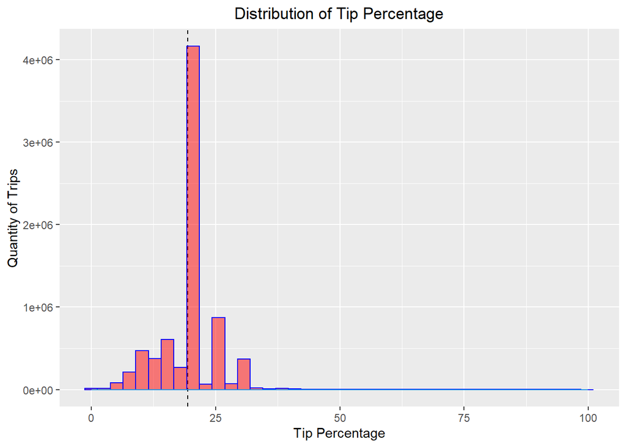

```r
ggplot(data=taxiTipData, aes(x=Tip_Percent))+
geom_vline(aes(xintercept = mean(Tip_Percent)), linetype = 2)+
geom_histogram(bins=40, fill='red', color="blue", alpha=0.5)+
geom_density(col=100) +
labs(x="Tip Percentage", y = "Quantity of Trips") +
ggtitle("Distribution of Tip Percentage") +
theme(plot.title = element_text(hjust = 0.5))
```

It is quite evident that there is a strong preference for tipping 20%, and that 20% is one of the aforementioned presets. It is also notable that though there is a noticeable tail towards higher tip percentages, they are dwarfed in impact by tips below 20%, resulting in an average tip of 19.43% for the dataset.

In an effort to pursue tips which are above average, we can now incorporate location data to our previous model in an effort to improve it.

```r
fitted_forest3 <- randomForest(formula = Tip_Percent ~ PU_Lat + PU_Long + Trip_Distance_Miles + Trip_Duration + hour + wday + month,
                              data = taxiTipData2,
                              ntree = 80, sampsize = 10000)

print(fitted_forest3)
```

```
##
## Call:
##  randomForest(formula = Tip_Percent ~ PU_Lat + PU_Long + Trip_Distance_Miles +      Trip_Duration + hour + wday + month, data = taxiTipData2,      ntree = 80, sampsize = 10000)
##                Type of random forest: regression
##                      Number of trees: 80
## No. of variables tried at each split: 2
##
##           Mean of squared residuals: 34.69012
##                     % Var explained: 1.65
```

```r
importance(fitted_forest3)
```

```
##                     IncNodePurity
## PU_Lat                   26319.38
## PU_Long                  25843.28
## Trip_Distance_Miles      51055.98
## Trip_Duration            58734.23
## hour                     30211.33
## wday                     18775.21
## month                    24812.66
```

Unfortunately, using location data does not appear to improve our model in this case. We may be attempting to use the wrong model or have the data in the incorrect format to test in this way. Despite the failure to improve the model, we are still able to utilize the neighborhood data in order to identify neighborhoods that tip above average. The resulting dataframe provides 3877 observations of pairings of Pickup and Dropoff with average and volume statistics. Trips which occured in too limited a quantity were excluded, as a trip which occurs once per year is not useful for planning where to focus your driving if you are attempting to maximize tips. Maybe you get lucky and land the single occurence trip and get excellent tips for that day but the low volume means that trip and the resulting tip are likely extremely infrequent. As a result, a minimum number of trips of 150 was selected, as this represents trips which should occur with some degree of frequency even if it’s not daily.

```r
## Best Tip Routes
bestTipRoute <-  taxiTipData %>%
  filter(Tip_Amount != 0, Pickup_Location_ID < 264, Dropoff_Location_ID < 264) %>%
  group_by(PU_Borough, PU_Neighbourhood, DO_Borough, DO_Neighbourhood) %>%
  summarise(avgTipPercentage = mean(Tip_Amount/Fare_Pre_Tip*100), AvgTipAmount = mean(Tip_Amount), PU_DO_Count = n())%>%
  filter(PU_DO_Count > 150) %>%
  arrange(desc(avgTipPercentage))

head(bestTipRoute, n=10)
```

```
## # A tibble: 10 x 7
## # Groups:   PU_Borough, PU_Neighbourhood, DO_Borough [8]
##    PU_Borough PU_Neighbourhood DO_Borough DO_Neighbourhood avgTipPercentage
##    <chr>      <chr>            <chr>      <chr>                       <dbl>
##  1 Queens     LaGuardia Airpo~ Queens     East Elmhurst                28.7
##  2 Queens     JFK Airport      Queens     Baisley Park                 23.4
##  3 Queens     LaGuardia Airpo~ Queens     Jackson Heights              23.1
##  4 Manhattan  SoHo             Manhattan  SoHo                         22.8
##  5 Brooklyn   Boerum Hill      Brooklyn   Brooklyn Heights             22.8
##  6 Manhattan  Financial Distr~ Manhattan  Financial Distr~             22.6
##  7 Manhattan  Financial Distr~ Manhattan  Financial Distr~             22.6
##  8 Queens     LaGuardia Airpo~ Queens     Steinway                     22.5
##  9 Brooklyn   East Williamsbu~ Brooklyn   Greenpoint                   22.5
## 10 Queens     Old Astoria      Queens     Astoria                      22.5
## # ... with 2 more variables: AvgTipAmount <dbl>, PU_DO_Count <int>
```

What if we were to however, only consider the pairings where the average tip Percentage is greater than the sample average and look at the volume of trips pairings. This still should yield higher than average tips, however we can identify neighborhoods with much larger volume numbers and identify a location with more frequent trips if a volume strategy is sought.

```r
sample_AvgTipPct <- mean(bestTipRoute$avgTipPercentage)
bestTipRoute2 <-  taxiTipData %>%
  filter(Tip_Amount != 0, Pickup_Location_ID < 264, Dropoff_Location_ID < 264) %>%
  group_by(PU_Borough, PU_Neighbourhood, DO_Borough, DO_Neighbourhood) %>%
  summarise(avgTipPercentage = mean(Tip_Amount/Fare_Pre_Tip*100), AvgTipAmount = mean(Tip_Amount), PU_DO_Count = n())%>%
  filter(avgTipPercentage>sample_AvgTipPct) %>%
  arrange(desc(PU_DO_Count))

head(bestTipRoute2, n=10)
```

```
## # A tibble: 10 x 7
## # Groups:   PU_Borough, PU_Neighbourhood, DO_Borough [5]
##    PU_Borough PU_Neighbourhood DO_Borough DO_Neighbourhood avgTipPercentage
##    <chr>      <chr>            <chr>      <chr>                       <dbl>
##  1 Manhattan  Upper East Side~ Manhattan  Upper East Side~             19.6
##  2 Manhattan  Upper East Side~ Manhattan  Upper East Side~             19.4
##  3 Manhattan  Upper East Side~ Manhattan  Upper East Side~             20.4
##  4 Manhattan  Upper East Side~ Manhattan  Upper East Side~             20.5
##  5 Manhattan  Upper West Side~ Manhattan  Upper West Side~             20.2
##  6 Manhattan  Upper West Side~ Manhattan  Lincoln Square ~             20.4
##  7 Manhattan  Lincoln Square ~ Manhattan  Upper West Side~             20.2
##  8 Manhattan  Upper East Side~ Manhattan  Midtown East                 19.8
##  9 Manhattan  Upper West Side~ Manhattan  Upper West Side~             20.1
## 10 Manhattan  Upper East Side~ Manhattan  Midtown Center               19.5
## # ... with 2 more variables: AvgTipAmount <dbl>, PU_DO_Count <int>
```

In this instance, we see lower average Tip Percentage, but substantially higher volume, while still earning above average tips by percent. Additionally, these locations are geographically distinct from what we saw in our previous case, though they have the same phenomenon of predominantly representing relatively short trips within one or two neighborhoods. If a cab driver were to focus on using a high volume strategy with frequent short trips earning above average tips, it seems that the neighborhoods surrounding central park would be a good place to start.

```r
sample_AvgTipPct <- mean(taxiTipData$Tip_Percent)

taxiTipData3 <- taxiTipData %>%
  filter(Tip_Amount != 0, Pickup_Location_ID < 264, Dropoff_Location_ID < 264) %>%
  group_by(wday, hour) %>%
  summarise(avgTipPercentage = mean(Tip_Amount/Fare_Pre_Tip*100), AvgTipAmount = mean(Tip_Amount), PU_DO_Count = n())%>%
  filter(avgTipPercentage>sample_AvgTipPct, PU_DO_Count > 150) %>%
  arrange(desc(avgTipPercentage))

head(taxiTipData3, n=20)
```

```
## # A tibble: 20 x 5
## # Groups:   wday [5]
##    wday   hour avgTipPercentage AvgTipAmount PU_DO_Count
##    <ord> <int>            <dbl>        <dbl>       <int>
##  1 Tue       2             20.3         2.76        5136
##  2 Tue       3             20.2         2.95        3140
##  3 Wed       4             20.1         3.93        4272
##  4 Tue       1             19.9         2.99        9688
##  5 Wed       1             19.9         2.83       12836
##  6 Mon       3             19.9         2.93        4284
##  7 Wed       2             19.9         2.74        7342
##  8 Thu       1             19.9         2.78       15246
##  9 Tue       0             19.9         3.17       19047
## 10 Mon      13             19.9         2.88       49461
## 11 Mon      11             19.9         2.84       46526
## 12 Sun       8             19.9         2.74       21043
## 13 Mon      12             19.9         2.84       49094
## 14 Tue      13             19.9         2.91       54325
## 15 Wed       3             19.8         2.79        4253
## 16 Sun       7             19.8         3.29       12723
## 17 Tue      12             19.8         2.88       54172
## 18 Wed      13             19.8         2.96       55308
## 19 Thu       2             19.8         2.62        8501
## 20 Mon      14             19.8         2.92       53772
```

### Drawing Conclusions

Additional testing is needed regardless, as the % of variance explained by the model is insufficient for predictive purposes. At this time, a prospective yellow cab driver would do best with the knowledge that late nights, in neighborhoods around Central Park are likely the best way to maximize Tip Percentage while still having a high volume of customers.